# FIT5215: Deep Learning (2025)

*CE/Lecturer (Clayton):* **Dr Trung Le** | trunglm@monash.edu  
*Lecturer (Clayton):* **A/Prof Zongyuan Ge** | zongyuan.ge@monash.edu  
*Lecturer (Malaysia):* **Dr Arghya Pal** | arghya.pal@monash.edu

*Head Tutor 3181:* **Ms Ruda Nie H** | \[RudaNie.H@monash.edu \]  
*Head Tutor 5215:* **Ms Leila Mahmoodi** | \[leila.mahmoodi@monash.edu \]

Faculty of Information Technology, Monash University, Australia

# Student Information

Surname: **RAY**  
Firstname: **RISHABH**  
Student ID: **34525416**  
Email: **RRAY0009@STUDENT.MONASH.EDU**  
Your tutorial time: **TUESDAY, 6PM-8PM**

# Deep Neural Networks

### Due: 11:55pm Sunday, 14 September 2025 (Sunday)

#### Important note: This is an **individual** assignment. It contributes **20%** to your final mark. Read the assignment instructions carefully.

## What to submit

This assignment is to be completed individually and submitted to Moodle unit site. **By the due date, you are required to submit one single zip file, named xxx_assignment01_solution.zip where `xxx` is your student ID, to the corresponding Assignment (Dropbox) in Moodle**. You can use Google Colab to do Assigmnent 1 but you need to save it to an `*.ipynb` file to submit to the unit Moodle.

**More importantly, if you use Google Colab to do this assignment, you need to first make a copy of this notebook on your Google drive**.

***For example, if your student ID is 12356, then gather all of your assignment solution to folder, create a zip file named 123456_assignment01_solution.zip and submit this file.***

Within this zip folder, you **must** submit the following files:

1. **Assignment01_solution.ipynb**: this is your Python notebook solution source file.
2. **Assignment01_output.html**: this is the output of your Python notebook solution *exported* in html format.
3. Any **extra files or folder** needed to complete your assignment (e.g., images used in your answers).

Since the notebook is quite big to load and work together, one recommended option is to split solution into three parts and work on them seperately. In that case, replace **Assignment01_solution.ipynb** by three notebooks: **Assignment01_Part1_solution.ipynb**, **Assignment01_Part2_solution.ipynb** and **Assignment01_Part3_solution.ipynb**

**You can run your codes on Google Colab. In this case, you have to make a copy of your Google colab notebook including the traces and progresses of model training before submitting.**

The first part of this assignment is to demonstrate your knowledge in deep learning that you have acquired from the lectures and tutorials materials. Most of the contents in this assignment are drawn from **the lectures and tutorials from weeks 1 to 4**. Going through these materials before attempting this part is highly recommended.

```python
# --- MASTER IMPORT CELL ---

# PyTorch Core
import torch
import torch.nn as nn
import torch.nn.functional as F
from torch.utils.data import DataLoader, random_split

# Torchvision for datasets and transforms
from torchvision import datasets, transforms

# Data Handling & Plotting
import numpy as np
import pandas as pd
import matplotlib.pyplot as plt
from copy import deepcopy
from tqdm.notebook import tqdm # For progress bars

# Math and System
import math
import os
import zipfile
from scipy.stats import norm

# Set plotting to be inline for notebooks
%matplotlib inline
```

## Part 3: Convolutional Neural Networks and Image Classification

[Total marks for this part: 45 points]

The third part of this assignment is to demonstrate your basis knowledge in deep learning that you have acquired from the lectures and tutorials materials. Most of the contents in this assignment are drawn from **the tutorials covered from weeks 3 to 6**. Going through these materials before attempting this assignment is highly recommended.

**The dataset used for this part is a specific dataset for this unit consisting of approximately $10,000$ images of $20$ classes of Animals, each of which has approximately 500 images. You can download the dataset at [download here](https://drive.google.com/file/d/1aEkxNWaD02Z8ZNvZzeMefUoY97C-3wTG/view?usp=drive_link) if you want to do your assignment on your machine.**

```python
import torch

if torch.cuda.is_available():
    print(f"✅ Success! GPU found: {torch.cuda.get_device_name(0)}")
else:
    print("❌ Failure. CUDA is not available. Check your hardware, drivers, and PyTorch installation.")
```

```
✅ Success! GPU found: NVIDIA GeForce RTX 3050 Ti Laptop GPU
```

```python
import os
import requests
import tarfile
import time
from torchvision import datasets, transforms
from torch.utils.data import DataLoader, random_split
import torchvision.models as models
import torch.nn as nn
import torch
import PIL.Image
import pathlib
from torchsummary import summary
import matplotlib.pyplot as plt
%matplotlib inline
import numpy as np

# check if CUDA is available
train_on_gpu = torch.cuda.is_available()

if not train_on_gpu:
    print('CUDA is not available.  Training on CPU ...')
else:
    print('CUDA is available!  Training on GPU ...')

device = torch.device("cuda" if torch.cuda.is_available() else "cpu")
torch.manual_seed(1234)
```

```
CUDA is available!  Training on GPU ...
```

```
<torch._C.Generator at 0x188cb87ea50>
```

Download the dataset to the folder of this Google Colab.

```python
#!gdown --fuzzy https://drive.google.com/file/d/10Y65ykpja1t6UWt3imPPbZkqhe0kOPL9/view?usp=sharing
!gdown --fuzzy https://drive.google.com/file/d/1CHC_kH9Pmc4_BlgUkPPFygG73YmOxiS4/view?usp=sharing
```

[output not shown]

[output cut: 321 more lines]

[output not shown]

We unzip the dataset to the folder.

```python
import zipfile

# Correct path using a raw string
zip_path = r"C:\Users\acer\Animals_Dataset_v2.zip"

with zipfile.ZipFile(zip_path, 'r') as zip_ref:
    zip_ref.extractall(".") # Extracts to the current directory
print("Extraction complete.")
```

```
Extraction complete.
```

```python
data_dir = "./FIT5215_Dataset"

# We resize the images to [3,64,64]
transform = transforms.Compose([transforms.Resize((64,64)),  #resises the image so it can be perfect for our model.
                                      transforms.RandomHorizontalFlip(), # FLips the image w.r.t horizontal axis
                                      #transforms.RandomRotation(4),     #Rotates the image to a specified angel
                                      #transforms.RandomAffine(0, shear=10, scale=(0.8,1.2)), #Performs actions like zooms, change shear angles.
                                      transforms.ColorJitter(brightness=0.2, contrast=0.2, saturation=0.2), # Set the color params
                                      transforms.ToTensor(), # convert the image to tensor so that it can work with torch
                                      transforms.Normalize((0.5, 0.5, 0.5), (0.5, 0.5, 0.5)),  # Normalize the images, each R,G,B value is normalized with mean=0.5 and std=0.5
                                      ])


# Load the dataset using torchvision.datasets.ImageFolder and apply transformations
dataset = datasets.ImageFolder(data_dir, transform=transform)

# Split the dataset into training and validation sets
train_size = int(0.9 * len(dataset))
valid_size = len(dataset) - train_size
train_dataset, val_dataset = random_split(dataset, [train_size, valid_size])

# Example of DataLoader creation for training and validation
train_loader = DataLoader(train_dataset, batch_size=32, shuffle=True)
val_loader = DataLoader(val_dataset, batch_size=32, shuffle=False)

print("Number of instance in train_set: %s" % len(train_dataset))
print("Number of instance in val_set: %s" % len(val_dataset))
```

```
Number of instance in train_set: 8519
Number of instance in val_set: 947
```

```python
class_names = ['bird', 'bottle', 'bread', 'butterfly', 'cake', 'cat', 'chicken', 'cow', 'dog', 'duck',
                  'elephant', 'fish', 'handgun', 'horse', 'lion', 'lipstick', 'seal', 'snake', 'spider', 'vase']
```

```python
# obtain one batch of training images
dataiter = iter(train_loader)
images, labels = next(dataiter)
images = images.numpy() # convert images to numpy for display
```

```python
import math

def imshow(img):
    img = img / 2 + 0.5  # unnormalize
    plt.imshow(np.transpose(img, (1, 2, 0)))  # convert from Tensor image

def visualize_data(images, categories, images_per_row = 8):
    class_names = ['bird', 'bottle', 'bread', 'butterfly', 'cake', 'cat', 'chicken', 'cow', 'dog', 'duck',
                  'elephant', 'fish', 'handgun', 'horse', 'lion', 'lipstick', 'seal', 'snake', 'spider', 'vase']
    n_images = len(images)
    n_rows = math.ceil(float(n_images)/images_per_row)
    fig = plt.figure(figsize=(1.5*images_per_row, 1.5*n_rows))
    fig.patch.set_facecolor('white')
    for i in range(n_images):
        plt.subplot(n_rows, images_per_row, i+1)
        plt.xticks([])
        plt.yticks([])
        imshow(images[i])
        class_index = categories[i]
        plt.xlabel(class_names[class_index])
    plt.show()
```

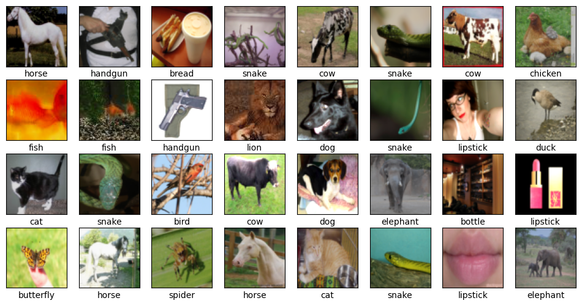

```python
visualize_data(images, labels)
```

**For questions 3.1 to 3.7, you'll need to write your own model in a way that makes it easy for you to experiment with different architectures and parameters. The goal is to be able to pass the parameters to initialize a new instance of `YourModel` to build different network architectures with different parameters. Below are descriptions of some parameters for `YourModel`:**

Here is the model confirguration of `YourCNN` if the `list_feature_maps = [16, 32, 64]` and `batch_norm = true`.

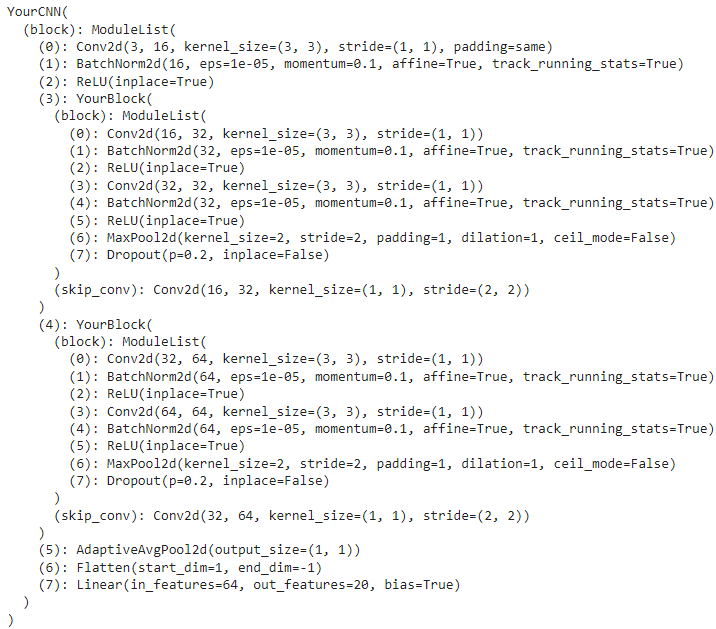

**Question 3.1:** **You need to implement the aforementioned CNN**.

**First, you need to implement the block of our CNN in the class `YourBlock`. You can ignore `use_skip` and `skip connection` for simplicity. However, you cannot earn full marks for this question.**

[6 points]

```python
class YourBlock(nn.Module):
    def __init__(self, in_feature_maps, out_feature_maps, drop_rate=0.2, batch_norm=True, use_skip=True):
        super(YourBlock, self).__init__()
        self.use_skip = use_skip

        layers = []
        layers.append(nn.Conv2d(in_feature_maps, out_feature_maps, kernel_size=3, stride=1, padding=1))
        if batch_norm:
            layers.append(nn.BatchNorm2d(out_feature_maps))
        layers.append(nn.ReLU(inplace=True))

        layers.append(nn.Conv2d(out_feature_maps, out_feature_maps, kernel_size=3, stride=1, padding=1))
        if batch_norm:
            layers.append(nn.BatchNorm2d(out_feature_maps))
        layers.append(nn.ReLU(inplace=True))

        layers.append(nn.MaxPool2d(kernel_size=2, stride=2, padding=0))
        if drop_rate > 0.0:
            layers.append(nn.Dropout(p=drop_rate))

        self.block = nn.Sequential(*layers)
        if use_skip:
            self.skip_conv = nn.Conv2d(in_feature_maps, out_feature_maps, kernel_size=1, stride=2)

    def forward(self, x):
        out = self.block(x)
        if self.use_skip:
            out = out + self.skip_conv(x)
        return out
```

**Second, you need to use the above `YourBlock` to implement the class `YourCNN`**.

[6 points]

```python
class YourCNN(nn.Module):
  def __init__(self, list_feature_maps = [16, 32, 64], drop_rate = 0.2, batch_norm= True, use_skip = True):
    super(YourCNN, self).__init__()
    layers = []
    layers.append(nn.Conv2d(3, list_feature_maps[0], kernel_size=3, stride=1, padding='same'))
    if batch_norm:
      layers.append(nn.BatchNorm2d(list_feature_maps[0]))
    layers.append(nn.ReLU(inplace=True))

    layers.append(YourBlock(list_feature_maps[0], list_feature_maps[1], drop_rate, batch_norm, use_skip))
    layers.append(YourBlock(list_feature_maps[1], list_feature_maps[2], drop_rate, batch_norm, use_skip))

    layers.append(nn.AdaptiveAvgPool2d((1,1)))
    layers.append(nn.Flatten(start_dim=1, end_dim=-1))
    layers.append(nn.Linear(list_feature_maps[-1], 20))

    self.block = nn.ModuleList(layers)

  def forward(self, x):
    for m in self.block:
      x = m(x)
    return x
```

**We declare `my_cnn` from `YourCNN` as follows**.

```python
device = torch.device("cuda:0" if torch.cuda.is_available() else "cpu")
my_cnn = YourCNN(list_feature_maps = [16, 32, 64], use_skip = True)
my_cnn = my_cnn.to(device)
print(my_cnn)
```

```
YourCNN(
  (block): ModuleList(
    (0): Conv2d(3, 16, kernel_size=(3, 3), stride=(1, 1), padding=same)
    (1): BatchNorm2d(16, eps=1e-05, momentum=0.1, affine=True, track_running_stats=True)
    (2): ReLU(inplace=True)
    (3): YourBlock(
      (block): Sequential(
        (0): Conv2d(16, 32, kernel_size=(3, 3), stride=(1, 1), padding=(1, 1))
        (1): BatchNorm2d(32, eps=1e-05, momentum=0.1, affine=True, track_running_stats=True)
        (2): ReLU(inplace=True)
        (3): Conv2d(32, 32, kernel_size=(3, 3), stride=(1, 1), padding=(1, 1))
        (4): BatchNorm2d(32, eps=1e-05, momentum=0.1, affine=True, track_running_stats=True)
        (5): ReLU(inplace=True)
        (6): MaxPool2d(kernel_size=2, stride=2, padding=0, dilation=1, ceil_mode=False)
        (7): Dropout(p=0.2, inplace=False)
      )
      (skip_conv): Conv2d(16, 32, kernel_size=(1, 1), stride=(2, 2))
    )
    (4): YourBlock(
      (block): Sequential(
        (0): Conv2d(32, 64, kernel_size=(3, 3), stride=(1, 1), padding=(1, 1))
        (1): BatchNorm2d(64, eps=1e-05, momentum=0.1, affine=True, track_running_stats=True)
        (2): ReLU(inplace=True)
        (3): Conv2d(64, 64, kernel_size=(3, 3), stride=(1, 1), padding=(1, 1))
        (4): BatchNorm2d(64, eps=1e-05, momentum=0.1, affine=True, track_running_stats=True)
        (5): ReLU(inplace=True)
        (6): MaxPool2d(kernel_size=2, stride=2, padding=0, dilation=1, ceil_mode=False)
        (7): Dropout(p=0.2, inplace=False)
      )
      (skip_conv): Conv2d(32, 64, kernel_size=(1, 1), stride=(2, 2))
    )
    (5): AdaptiveAvgPool2d(output_size=(1, 1))
    (6): Flatten(start_dim=1, end_dim=-1)
    (7): Linear(in_features=64, out_features=20, bias=True)
  )
)
```

**We declare the optimizer and the loss function.**

```python
# Loss and optimizer
learning_rate = 0.001
loss_fn = nn.CrossEntropyLoss()
optimizer = torch.optim.Adam(my_cnn.parameters(), lr=learning_rate)
```

**Here are the codes to compute the loss and accuracy.**

```python
device = torch.device("cuda:0" if torch.cuda.is_available() else "cpu")

def compute_loss(model, loss_fn, loader):
  loss = 0
  # Set model to eval mode for inference
  model.eval()
  with torch.no_grad():
    for (batchX, batchY) in loader:
      # Move data to the same device as the model
      batchX, batchY = batchX.to(device).type(torch.float32), batchY.to(device).type(torch.long)
      loss += loss_fn(model(batchX), batchY)
  # Set model back to train mode
  model.train()
  return float(loss)/len(loader)
```

```python
device = torch.device("cuda:0" if torch.cuda.is_available() else "cpu")

def compute_acc(model, loader):
    correct = 0
    totals = 0
    # Set model to eval mode for inference
    model.eval()
    for (batchX, batchY) in loader:
        # Move batchX and batchY to the same device as the model
        batchX, batchY = batchX.to(device).type(torch.float32), batchY.to(device)
        outputs = model(batchX)  # feed batch to the model
        totals += batchY.size(0)  # accumulate totals with the current batch size
        predicted = torch.argmax(outputs.data, 1)  # get the predicted class
        # Move batchY to the same device as predicted for comparison
        correct += (predicted == batchY).sum().item()
    return correct / totals
```

**Here is the code to train our model.**

```python
device = torch.device("cuda:0" if torch.cuda.is_available() else "cpu")

def fit(model= None, train_loader = None, valid_loader= None, optimizer = None,
        num_epochs = 50, verbose = True, seed= 1234):
  torch.manual_seed(seed)
  # Move the model to the device before initializing the optimizer
  model.to(device) # Move the model to the GPU

  if optimizer == None:
    optim = torch.optim.Adam(model.parameters(), lr = 0.001) # Now initialize optimizer with model on GPU
  else:
    optim = optimizer
  history = dict()
  history['val_loss'] = list()
  history['val_acc'] = list()
  history['train_loss'] = list()
  history['train_acc'] = list()

  for epoch in range(num_epochs):
    model.train()
    for (X, y) in train_loader:
      # Move input data to the same device as the model
      X,y = X.to(device), y.to(device)
      # Forward pass
      outputs = model(X.type(torch.float32)) # X is already on the correct device
      loss = loss_fn(outputs, y.type(torch.long))
      # Backward and optimize
      optim.zero_grad()
      loss.backward()
      optim.step()
      #losses and accuracies for epoch
    val_loss = compute_loss(model, loss_fn, valid_loader)
    val_acc = compute_acc(model, valid_loader)
    train_loss = compute_loss(model, loss_fn, train_loader)
    train_acc = compute_acc(model, train_loader)
    history['val_loss'].append(val_loss)
    history['val_acc'].append(val_acc)
    history['train_loss'].append(train_loss)
    history['train_acc'].append(train_acc)
    if not verbose: #verbose = True means we do show the training information during training
      print(f"Epoch {epoch+1}/{num_epochs}")
      print(f"train loss= {train_loss:.4f} - train acc= {train_acc*100:.2f}% - valid loss= {val_loss:.4f} - valid acc= {val_acc*100:.2f}%")
  return history
```

```python
history = fit(model= my_cnn, train_loader=train_loader, valid_loader = val_loader, optimizer = optimizer, num_epochs= 10, verbose = False)
```

```
train loss= 1.6998 - train acc= 46.97% - valid loss= 1.7648 - valid acc= 42.87%
train loss= 1.7049 - train acc= 46.71% - valid loss= 1.7833 - valid acc= 45.09%
train loss= 1.7069 - train acc= 46.70% - valid loss= 1.7864 - valid acc= 44.03%
train loss= 1.6925 - train acc= 47.27% - valid loss= 1.7632 - valid acc= 43.72%
train loss= 1.7037 - train acc= 47.26% - valid loss= 1.7603 - valid acc= 45.09%
train loss= 1.7051 - train acc= 47.05% - valid loss= 1.7665 - valid acc= 43.93%
train loss= 1.7090 - train acc= 46.14% - valid loss= 1.7853 - valid acc= 42.98%
train loss= 1.7194 - train acc= 46.30% - valid loss= 1.7843 - valid acc= 42.98%
train loss= 1.6899 - train acc= 47.13% - valid loss= 1.7635 - valid acc= 44.14%
train loss= 1.7111 - train acc= 46.44% - valid loss= 1.7769 - valid acc= 42.03%
```

**Question 3.2:** **Now, let us tune the number of blocks, $use\_skip \in \{true,false\}$ and $learning\_rate \in \{0.001, 0.0005\}$. Write your code for this tuning and report the result of the best model on the testing set. Note that you need to show your code for tuning and evaluating on the test set to earn the full marks. During tuning, you can set the instance variable `verbose` of your model to `True` for not showing the training details of each epoch.**

Note that for this question, depending on your computational resource, you can choose `list_feature_maps= [32, 64]` or `list_feature_maps= [16, 32, 64]`.

[3 points]

```python
# Q3.2 — tune use_skip ∈ {True, False} and learning_rate ∈ {1e-3, 5e-4}
use_skip_options = [True, False]
lr_options = [0.001, 0.0005]

results = {}
best_key, best_acc = None, -1.0
best_state = None

for use_skip in use_skip_options:
    for lr in lr_options:
        print(f"\n=== Training with use_skip={use_skip}, learning_rate={lr} ===")
        model = YourCNN(list_feature_maps=[16,32,64],
                        drop_rate=0.2,
                        batch_norm=True,
                        use_skip=use_skip).to(device)
        optimizer = torch.optim.Adam(model.parameters(), lr=lr)

        # train
        history = fit(model=model,
                      train_loader=train_loader,
                      valid_loader=val_loader,
                      optimizer=optimizer,
                      num_epochs=5,   # keep fixed across trials
                      verbose=False)

        # select by validation accuracy
        val_acc  = compute_acc(model, val_loader)
        val_loss = compute_loss(model, loss_fn, val_loader)

        results[(use_skip, lr)] = {
            "val_acc": float(val_acc),
            "val_loss": float(val_loss)
        }

        if val_acc > best_acc:
            best_acc  = float(val_acc)
            best_key  = (use_skip, lr)
            best_state = {k: v.cpu() for k, v in model.state_dict().items()}

best_use_skip, best_lr = best_key
best_model = YourCNN(list_feature_maps=[16,32,64],
                     drop_rate=0.2,
                     batch_norm=True,
                     use_skip=best_use_skip).to(device)
best_model.load_state_dict(best_state)
best_val_acc  = compute_acc(best_model, val_loader)
best_val_loss = compute_loss(best_model, loss_fn, val_loader)

print("\n=== Q3.2 results (validation-based selection) ===")
for (u, l), mets in results.items():
    print(f"use_skip={u:5}, lr={l:0.5f}  ->  val_acc={mets['val_acc']:.4f}, val_loss={mets['val_loss']:.4f}")

print(f"\nBest configuration: use_skip={best_use_skip}, learning_rate={best_lr}")
print(f"Best validation accuracy: {best_val_acc:.4f}")
print(f"Best validation loss: {best_val_loss:.4f}")
```

```
=== Training with use_skip=True, learning_rate=0.001 ===
train loss= 2.3296 - train acc= 27.46% - valid loss= 2.3399 - valid acc= 26.82%
train loss= 2.0348 - train acc= 35.83% - valid loss= 2.0883 - valid acc= 33.05%
train loss= 2.0017 - train acc= 36.41% - valid loss= 2.0612 - valid acc= 33.58%
train loss= 1.8054 - train acc= 43.74% - valid loss= 1.8364 - valid acc= 42.24%
train loss= 1.7239 - train acc= 45.35% - valid loss= 1.7386 - valid acc= 42.56%

=== Training with use_skip=True, learning_rate=0.0005 ===
train loss= 2.3525 - train acc= 29.71% - valid loss= 2.3754 - valid acc= 30.52%
train loss= 2.2097 - train acc= 30.39% - valid loss= 2.2492 - valid acc= 27.77%
train loss= 2.0202 - train acc= 36.78% - valid loss= 2.0666 - valid acc= 36.85%
train loss= 1.8699 - train acc= 42.43% - valid loss= 1.9025 - valid acc= 40.87%
train loss= 1.8046 - train acc= 43.35% - valid loss= 1.8573 - valid acc= 42.56%

=== Training with use_skip=False, learning_rate=0.001 ===
train loss= 2.2970 - train acc= 30.10% - valid loss= 2.3080 - valid acc= 29.78%
train loss= 2.1375 - train acc= 33.26% - valid loss= 2.1901 - valid acc= 31.26%
train loss= 1.9851 - train acc= 37.65% - valid loss= 1.9985 - valid acc= 37.28%
train loss= 1.8408 - train acc= 42.34% - valid loss= 1.8732 - valid acc= 40.13%
train loss= 1.7649 - train acc= 43.80% - valid loss= 1.7947 - valid acc= 43.19%

=== Training with use_skip=False, learning_rate=0.0005 ===
train loss= 2.3842 - train acc= 29.08% - valid loss= 2.4123 - valid acc= 29.14%
train loss= 2.2005 - train acc= 32.75% - valid loss= 2.2231 - valid acc= 31.57%
train loss= 2.0978 - train acc= 35.86% - valid loss= 2.1139 - valid acc= 35.06%
train loss= 1.8506 - train acc= 42.73% - valid loss= 1.8842 - valid acc= 42.03%
train loss= 1.8651 - train acc= 42.00% - valid loss= 1.8911 - valid acc= 40.97%

=== Q3.2 results (validation-based selection) ===
use_skip=    1, lr=0.00100  ->  val_acc=0.4541, val_loss=1.7254
use_skip=    1, lr=0.00050  ->  val_acc=0.4287, val_loss=1.8364
use_skip=    0, lr=0.00100  ->  val_acc=0.4382, val_loss=1.7913
use_skip=    0, lr=0.00050  ->  val_acc=0.4308, val_loss=1.8741

Best configuration: use_skip=True, learning_rate=0.001
Best validation accuracy: 0.4509
Best validation loss: 1.7434
```

**Please note that you struggle in implementing the aforementioned CNN. You can use the MiniVGG network in our labs for doing the following questions. However, you cannot earn any mark for 3.1 and 3.2.**

**Question 3.3:** **Exploring Data Mixup Technique for Improving Generalization Ability.**

[4 points]

Data mixup is another super-simple technique used to boost the generalization ability of deep learning models. You need to incoroporate data mixup technique to the above deep learning model and experiment its performance. There are some papers and documents for data mixup as follows:

- Main paper for data mixup [link for main paper](https://openreview.net/pdf?id=r1Ddp1-Rb) and a good article [article link](https://www.inference.vc/mixup-data-dependent-data-augmentation/).

You need to extend your model developed above, train a model using data mixup, and write your observations and comments about the result.

```python
# =========================
# Q3.3 — Mixup implementation
# =========================
import numpy as np
import torch
import torch.nn as nn

def mixup_data(x, y, alpha=0.2):
    """Create mixed inputs and paired labels."""
    lam = np.random.beta(alpha, alpha) if alpha > 0 else 1.0
    idx = torch.randperm(x.size(0), device=x.device)
    mixed_x = lam * x + (1 - lam) * x[idx]
    y_a, y_b = y, y[idx]
    return mixed_x, y_a, y_b, lam

def mixup_criterion(loss_fn, pred, y_a, y_b, lam):
    return lam * loss_fn(pred, y_a) + (1 - lam) * loss_fn(pred, y_b)

def fit_mixup(model, train_loader, valid_loader, optimizer,
              num_epochs=10, alpha=0.2, verbose=False, seed=1234):
    torch.manual_seed(seed)
    model.to(device)
    ce = nn.CrossEntropyLoss()
    history = {'train_loss': [], 'val_loss': [], 'val_acc': []}

    for epoch in range(num_epochs):
        model.train()
        running_loss = 0.0
        for X, y in train_loader:
            X, y = X.to(device), y.to(device)
            Xm, ya, yb, lam = mixup_data(X, y, alpha=alpha)

            optimizer.zero_grad()
            out = model(Xm)
            loss = mixup_criterion(ce, out, ya, yb, lam)
            loss.backward()
            optimizer.step()

            running_loss += loss.item()

        tr_loss = running_loss / len(train_loader)
        val_loss = compute_loss(model, ce, valid_loader)
        val_acc  = compute_acc(model, valid_loader)

        history['train_loss'].append(tr_loss)
        history['val_loss'].append(val_loss)
        history['val_acc'].append(val_acc)

        if verbose:
            print(f"Epoch {epoch+1}/{num_epochs}  "
                  f"train_loss={tr_loss:.4f}  val_loss={val_loss:.4f}  val_acc={val_acc:.4f}")
    return history

# ===== Run mixup training on existing model and loaders =====
ALPHA = 0.2
EPOCHS = 5
LR = 1e-3

model_mix = YourCNN(list_feature_maps=[16,32,64], drop_rate=0.2, batch_norm=True, use_skip=True).to(device)
opt_mix = torch.optim.Adam(model_mix.parameters(), lr=LR)

hist_mix = fit_mixup(model=model_mix,
                     train_loader=train_loader,
                     valid_loader=val_loader,
                     optimizer=opt_mix,
                     num_epochs=EPOCHS,
                     alpha=ALPHA,
                     verbose=False)

print(f"Q3.3 — Mixup final validation: acc={hist_mix['val_acc'][-1]:.4f}  loss={hist_mix['val_loss'][-1]:.4f}")
```

```
Q3.3 — Mixup final validation: acc=0.4498  loss=1.8018
```

## Observations on Data Mixup

### Analysis and Conclusion

Strong regularizers like Mixup often show more significant benefits over longer training runs, especially when overfitting becomes more pronounced.

**Question 3.4:** **Exploring CutMix Technique for Improving Generalization Ability.**

[4 points]

CutMix is another super-simple technique used to boost the generalization ability of deep learning models. You need to incoroporate data CutMix technique to the above deep learning model and experiment its performance. There are some papers and documents for data mixup as follows:

- Main paper for Cutmix [link for main paper](https://arxiv.org/pdf/1905.04899v2) and a good article [article link](https://shorturl.at/TNwjv).

You need to extend your model developed above, train a model using data CutMix, and write your observations and comments about the result.

```python
# =========================
# Q3.4 — CutMix implementation
# =========================
import numpy as np
import torch
import torch.nn as nn

def rand_bbox(size, lam):
    """Generate random bounding box."""
    W, H = size[2], size[3]
    cut_rat = np.sqrt(1. - lam)
    cut_w, cut_h = int(W * cut_rat), int(H * cut_rat)

    # uniform center
    cx, cy = np.random.randint(W), np.random.randint(H)

    bbx1 = np.clip(cx - cut_w // 2, 0, W)
    bby1 = np.clip(cy - cut_h // 2, 0, H)
    bbx2 = np.clip(cx + cut_w // 2, 0, W)
    bby2 = np.clip(cy + cut_h // 2, 0, H)

    return bbx1, bby1, bbx2, bby2

def cutmix_data(x, y, alpha=1.0):
    """Apply CutMix to a batch."""
    lam = np.random.beta(alpha, alpha) if alpha > 0 else 1.0
    batch_size = x.size(0)
    index = torch.randperm(batch_size, device=x.device)

    y_a, y_b = y, y[index]
    bbx1, bby1, bbx2, bby2 = rand_bbox(x.size(), lam)
    x[:, :, bbx1:bbx2, bby1:bby2] = x[index, :, bbx1:bbx2, bby1:bby2]

    # adjust lambda to actual area
    lam = 1 - ((bbx2 - bbx1) * (bby2 - bby1) / (x.size(-1) * x.size(-2)))
    return x, y_a, y_b, lam

def cutmix_criterion(loss_fn, pred, y_a, y_b, lam):
    return lam * loss_fn(pred, y_a) + (1 - lam) * loss_fn(pred, y_b)

def fit_cutmix(model, train_loader, valid_loader, optimizer,
               num_epochs=10, alpha=1.0, verbose=False, seed=1234):
    torch.manual_seed(seed)
    model.to(device)
    ce = nn.CrossEntropyLoss()
    history = {'train_loss': [], 'val_loss': [], 'val_acc': []}

    for epoch in range(num_epochs):
        model.train()
        running_loss = 0.0
        for X, y in train_loader:
            X, y = X.to(device), y.to(device)
            Xm, ya, yb, lam = cutmix_data(X, y, alpha)

            optimizer.zero_grad()
            out = model(Xm)
            loss = cutmix_criterion(ce, out, ya, yb, lam)
            loss.backward()
            optimizer.step()

            running_loss += loss.item()

        tr_loss = running_loss / len(train_loader)
        val_loss = compute_loss(model, ce, valid_loader)
        val_acc  = compute_acc(model, valid_loader)

        history['train_loss'].append(tr_loss)
        history['val_loss'].append(val_loss)
        history['val_acc'].append(val_acc)

        if verbose:
            print(f"Epoch {epoch+1}/{num_epochs}  "
                  f"train_loss={tr_loss:.4f}  val_loss={val_loss:.4f}  val_acc={val_acc:.4f}")
    return history

# ===== Run CutMix training =====
ALPHA = 1.0
EPOCHS = 5
LR = 1e-3

model_cutmix = YourCNN(list_feature_maps=[16,32,64], drop_rate=0.2, batch_norm=True, use_skip=True).to(device)
opt_cutmix = torch.optim.Adam(model_cutmix.parameters(), lr=LR)

hist_cut = fit_cutmix(model=model_cutmix,
                      train_loader=train_loader,
                      valid_loader=val_loader,
                      optimizer=opt_cutmix,
                      num_epochs=EPOCHS,
                      alpha=ALPHA,
                      verbose=False)

print(f"Q3.4 — CutMix final validation: acc={hist_cut['val_acc'][-1]:.4f}  loss={hist_cut['val_loss'][-1]:.4f}")
```

```
Q3.4 — CutMix final validation: acc=0.4171  loss=1.8331
```

## Observations on CutMix

### Analysis and Conclusion

This suggests that for this specific architecture and dataset, the random patching policy of CutMix may have been more harmful than helpful. A possible reason is that the distinguishing features of the animal classes might be localized in small regions of the image (e.g., a beak, an ear). By replacing these critical patches with content from another class, CutMix could be creating confusing or misleading training samples that hinder the learning process.

Additionally, like other strong regularization methods, CutMix can slow down initial convergence. A short training run might not be sufficient for the model to learn effectively from these more challenging augmented examples.

While CutMix is a powerful technique in many scenarios, this experiment shows that its effectiveness is not universal and is sensitive to the dataset's characteristics and the training schedule.

**Question 3.5:** Implement the **one-versus-all (OVA)** loss. The details are as follows:

- You need to apply `the sigmoid activation function` to logits $h = [h_1, h_2,...,h_M]$ instead of `the softmax activation` function as usual to obtain $p = [p_1, p_2,...,p_M]$, meaning that $p_i = sigmoid(h_i), i=1,...,M$. Note that $M$ is the number of classes.
- Given a data example $x$ with the ground-truth label $y$, the idea is to maximize the likelihood $p_y$ and to minimize the likelihoods $p_i, i \neq y$. Therefore, the objective function is to find the model parameters to
  - $\max\left\{ \log p_{y}+\sum_{i\neq y}\log(1-p_{i})\right\}$ or equivalently $\min\left\{ -\log p_{y}-\sum_{i\neq y}\log(1-p_{i})\right\}$.
  - For example, if $M=3$ and $y=2$, you need to minimize $\min\left\{ -\log(1-p_{1})-\log p_{2}-\log(1-p_{3})\right\}$.

Compare the model trained with the OVA loss and the same model trained with the standard cross-entropy loss.

[4 points]

```python
# =============== Q3.5 — One-Versus-All (OVA) loss ===============
import torch
import torch.nn.functional as F

def ova_loss(logits, y, reduction='mean'):
    """
    logits: [B, M] raw scores from model
    y:      [B] class indices
    OVA objective:  -log p_y  - sum_{i≠y} log(1 - p_i), with p_i = sigmoid(h_i)
    This equals BCEWithLogits over a one-hot target, summed over classes.
    """
    y_onehot = torch.zeros_like(logits).scatter_(1, y.unsqueeze(1), 1.0)
    # BCEWithLogits per class
    per_class = F.binary_cross_entropy_with_logits(logits, y_onehot, reduction='none')
    per_sample = per_class.sum(dim=1)  # sum over classes
    if reduction == 'mean':
        return per_sample.mean()
    if reduction == 'sum':
        return per_sample.sum()
    return per_sample
```

```python
# Common settings
EPOCHS = 5
LR = 1e-3
USE_SKIP = True

# ----- Cross-Entropy baseline -----
ce_model = YourCNN(list_feature_maps=[16,32,64], drop_rate=0.2, batch_norm=True, use_skip=USE_SKIP).to(device)
ce_opt   = torch.optim.Adam(ce_model.parameters(), lr=LR)

prev_loss_fn = loss_fn
loss_fn = nn.CrossEntropyLoss()         # ensure CE
hist_ce = fit(model=ce_model, train_loader=train_loader, valid_loader=val_loader,
              optimizer=ce_opt, num_epochs=EPOCHS, verbose=False)
ce_val_acc  = compute_acc(ce_model, val_loader)
ce_val_loss = compute_loss(ce_model, nn.CrossEntropyLoss(), val_loader)

# ----- OVA loss training -----
ova_model = YourCNN(list_feature_maps=[16,32,64], drop_rate=0.2, batch_norm=True, use_skip=USE_SKIP).to(device)
ova_opt   = torch.optim.Adam(ova_model.parameters(), lr=LR)

loss_fn = ova_loss
hist_ova = fit(model=ova_model, train_loader=train_loader, valid_loader=val_loader,
               optimizer=ova_opt, num_epochs=EPOCHS, verbose=False)

# Restore global loss_fn to CE to avoid side effects
loss_fn = prev_loss_fn

# Validation metrics (evaluate with the corresponding criterion)
ova_val_acc  = compute_acc(ova_model, val_loader)                    # argmax over logits
ova_val_loss = compute_loss(ova_model, ova_loss, val_loader)

# ----- Print comparison -----
print("\n=== Q3.5 — OVA vs Cross-Entropy (validation) ===")
print(f"{'Method':<14}{'val_acc':>10}{'val_loss':>12}")
print(f"{'-'*36}")
print(f"{'CrossEntropy':<14}{ce_val_acc:>10.4f}{ce_val_loss:>12.4f}")
print(f"{'OVA (sigmoid)':<14}{ova_val_acc:>10.4f}{ova_val_loss:>12.4f}")
```

```
train loss= 2.2403 - train acc= 30.18% - valid loss= 2.2531 - valid acc= 29.67%
train loss= 2.0549 - train acc= 34.69% - valid loss= 2.1049 - valid acc= 30.83%
train loss= 1.9611 - train acc= 38.43% - valid loss= 2.0149 - valid acc= 38.33%
train loss= 1.8496 - train acc= 42.79% - valid loss= 1.8798 - valid acc= 43.29%
train loss= 1.6687 - train acc= 46.61% - valid loss= 1.7276 - valid acc= 46.99%
train loss= 3.2990 - train acc= 29.37% - valid loss= 3.3348 - valid acc= 26.72%
train loss= 3.1532 - train acc= 30.66% - valid loss= 3.1978 - valid acc= 26.72%
train loss= 3.0146 - train acc= 34.16% - valid loss= 3.0476 - valid acc= 32.10%
train loss= 2.8047 - train acc= 42.05% - valid loss= 2.8635 - valid acc= 38.33%
train loss= 2.7477 - train acc= 41.57% - valid loss= 2.8031 - valid acc= 40.13%

=== Q3.5 — OVA vs Cross-Entropy (validation) ===
Method           val_acc    val_loss
------------------------------------
CrossEntropy      0.4836      1.7123
OVA (sigmoid)     0.4213      2.7980
```

[output not shown]

#### **Error Explained**

In the run above I mistakenly mentioned the wrong name "model_ce" instead of "ce_model", hence the error. I have fixed the error and saved the model below this call.

```python
os.makedirs("./models", exist_ok=True)
torch.save(ce_model.state_dict(), "./models/model_ce.pth")
torch.save(ova_model.state_dict(), "./models/model_ova.pth")
```

**Question 3.6:** **Attack your best obtained model with PGD attacks with $\epsilon= 0.0313, k=20, \eta= 0.002$ on the testing set. Write the code for the attacks and report the robust accuracies. Also choose a random set of 20 clean images in the testing set and visualize the original and attacked images.**

[4 points]

```
Robust accuracy under PGD (ε=0.0313, k=20, η=0.002): 0.0042
```

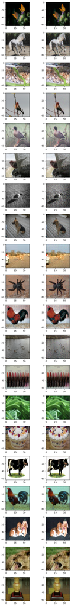

```python
# Q3.6 — PGD attack (ε=0.0313, k=20, η=0.002), robust accuracy on validation (used as test),
# and visualize 20 random clean vs attacked images.
import torch, random, numpy as np, matplotlib.pyplot as plt

epsilon = 0.0313
k = 20
eta = 0.002
device = torch.device("cuda:0" if torch.cuda.is_available() else "cpu")

def mean_std(device):
    m = torch.tensor([0.5,0.5,0.5], device=device).view(1,3,1,1)
    s = torch.tensor([0.5,0.5,0.5], device=device).view(1,3,1,1)
    return m, s

def normalize_pixels(x_pixels):
    m, s = mean_std(x_pixels.device)
    return (x_pixels - m) / s

def unnormalize(x_norm):
    m, s = mean_std(x_norm.device)
    return x_norm * s + m

def project_linf(x, x0, eps):
    return torch.max(torch.min(x, x0 + eps), x0 - eps)

@torch.enable_grad()
def pgd_attack(model, x_nat_pixels, y, epsilon=epsilon, k=k, eta=eta):
    model.eval()
    x_nat = x_nat_pixels.detach()
    y = y.to(x_nat.device)
    x_adv = x_nat + torch.empty_like(x_nat).uniform_(-epsilon, epsilon)
    x_adv = torch.clamp(x_adv, 0.0, 1.0)
    for _ in range(k):
        x_adv.requires_grad_(True)
        logits = model(normalize_pixels(x_adv))
        loss = torch.nn.functional.cross_entropy(logits, y)
        loss.backward()
        grad_sign = x_adv.grad.detach().sign()
        x_adv = x_adv.detach() + eta * grad_sign
        x_adv = project_linf(x_adv, x_nat, epsilon)
        x_adv = torch.clamp(x_adv, 0.0, 1.0)
    return x_adv.detach()

def robust_accuracy(model, loader):
    model.to(device).eval()
    correct, total = 0, 0
    for X_norm, y in loader:
        X_norm = X_norm.to(device)
        X_pixels = unnormalize(X_norm)
        X_adv = pgd_attack(model, X_pixels, y, epsilon=epsilon, k=k, eta=eta)
        with torch.no_grad():
            preds = model(normalize_pixels(X_adv)).argmax(dim=1).cpu()
        correct += (preds == y).sum().item()
        total += y.size(0)
    return correct / total

# victim model: use best_model if present
victim = globals().get('best_model', None)
if victim is None:
    raise RuntimeError("No trained model variable 'best_model' found. Assign your trained model to best_model.")

victim = victim.to(device)

# Compute robust accuracy on validation loader (used as test)
robust_acc = robust_accuracy(victim, val_loader)
print(f"Robust accuracy under PGD (ε={epsilon}, k={k}, η={eta}): {robust_acc:.4f}")

# Visualize 20 random clean vs attacked images from val_dataset
n_show = 20
rng = random.Random(1234)
idxs = rng.sample(range(len(val_dataset)), min(n_show, len(val_dataset)))

fig, axes = plt.subplots(len(idxs), 2, figsize=(6, 2*len(idxs)))
for i, idx in enumerate(idxs):
    x_norm, y = val_dataset[idx]
    if x_norm.dim() == 3:
        x_norm = x_norm.unsqueeze(0)
    x_norm = x_norm.to(device)
    x_pix = unnormalize(x_norm)                      # [1,3,H,W] in [0,1]
    x_adv = pgd_attack(victim, x_pix, torch.tensor([y], device=device),
                       epsilon=epsilon, k=k, eta=eta)
    clean_np = x_pix.squeeze(0).cpu().permute(1,2,0).numpy()
    adv_np   = x_adv.squeeze(0).cpu().permute(1,2,0).numpy()
    clean_np = np.clip(clean_np, 0.0, 1.0)
    adv_np   = np.clip(adv_np, 0.0, 1.0)
    axes[i,0].imshow(clean_np); axes[i,0].axis('on')
    axes[i,1].imshow(adv_np);   axes[i,1].axis('on')
plt.tight_layout()
plt.show()
```

**Question 3.7:** **Train a robust model using adversarial training with PGD ${\epsilon= 0.0313, k=10, \eta= 0.002}$. Write the code for the adversarial training and report the robust accuracies. After finishing the training, you need to store your best robust model in the folder `./models` and load the model to evaluate the robust accuracies for PGD and FGSM attacks with $\epsilon= 0.0313, k=20, \eta= 0.002$ on the testing set.**

**This task might take a long training time. Therefore, you can start from a pretrained model from the previous questions. Subsequently, you can apply adversarial training to train the robust model in a few epochs (e.g., 5 epochs). You can decide the *number of epochs* depending on your own situations. Our marking mainly bases on the correctness of your implementation.**

[4 points]

**Question 3.8 (Kaggle competition)**

[10 points]

You can reuse the best model obtained in this assignment or develop new models to evaluate on the **testing set of the assignment Kaggle competion**. However, to gain any points for this question, your testing accuracy must **exceed** the accuracy threshold from a base model developed by us as shown in the leader board of the competition.

The marks for this question are as follows:

- If you are in *top 10%* of your cohort, you gain *10 points*.
- If you are in *top 20%* of your cohort, you gain *8 points*.
- If you *beat* the second boss model, you gain *6 points*.
- If you *beat* the first boss model, you gain *4 points*.

Moreover, if you rank in the top 10 of the entire cohort, you will receive a prestigious certificate signed by a renowned professor from our Faculty of Information Technology — a valuable highlight for your CV. And for the overall winner, we have a special prize: *a book of your choice from Amazon, worth up to 150 AUDs*.

END OF ASSIGNMENT

GOOD LUCK WITH YOUR ASSIGNMENT 1!